# scStalt tutorial

Qing Luo

18/08/2022

## Summary

scStalt porvides a scalable ultrafast method to annotate cell states under the reference-query mode. It extracts the trajectory associated differentially expressed genes from reference dataset and then smoothed the genes to form a kernel expression profile with which query cells are assigned to their corresponding stages. The method can also be utilized to perform integration with mosaic datasets.

In this tutorial, we will generate two moscaic differential datasets, each encompassing varied cellular stages. And then we will use scStalt to infer the psuedotime of the query dataset as well as integrate the two datasets with batch correction.

### Preparation

```r
suppressMessages(library(Seurat))
suppressMessages(library(slingshot))
suppressMessages(library(splatter))
suppressMessages(library(RColorBrewer))
suppressMessages(library(tradeSeq))
suppressMessages(library(SeuratWrappers))
suppressMessages(library(harmony))
suppressMessages(library(scater))
suppressMessages(library(mclust, quietly = TRUE))
suppressMessages(library(MLmetrics))
suppressMessages(library(scStalt))
clustercol=c("#eeac99", "#77AADD",   "#c1946a", "#82b74b", "#034f84",  "#b8a9c9", "#F5DEB3", "#7e4a35")
```

```r
load("./data/b1_sub.Rda")
load("./data/b2_sub.Rda")
bm = merge(b1_sub,b2_sub)

t = data.frame(table(bm$col))
colnames(t) = c("Cell type","Cell number")
knitr::kable(t, "simple")
```

| Cell type | Cell number |
| --- | --- |
| A_batch1 | 546 |
| B_batch2 | 114 |
| C_batch1 | 553 |
| D_batch2 | 114 |
| E_batch1 | 598 |

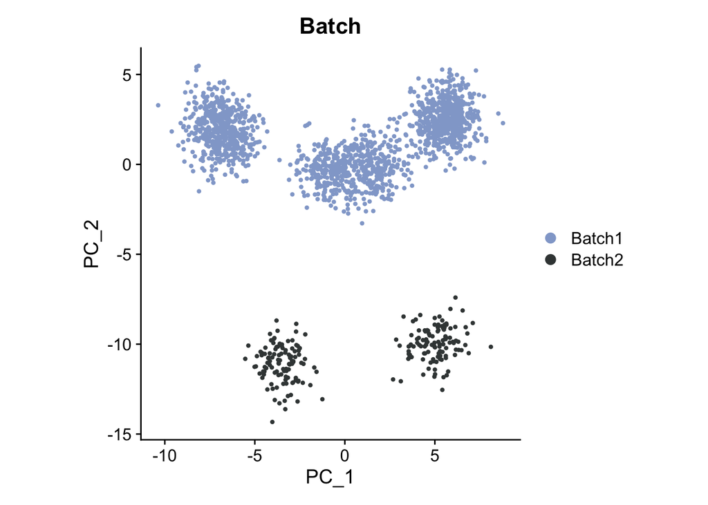

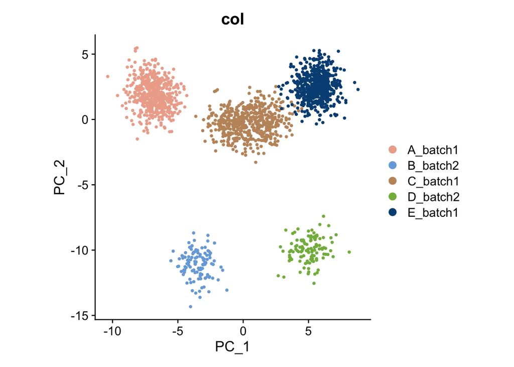

### Workflow

#### Step 2

Then we will obtian the kernel gene expression profile using function doKernel.

```r
library(scStalt)


ref = doKernel(count=b1_sub@assays$originalexp@counts, pseudotime = pseudotime, cellWeights = cellWeights, nGenes = 2000, nKnots = 5,nPoints = 100, fdr = 0.05)

#the paramater nKnots can be optimized using tradeSeq pipeline
```

#### Step 3

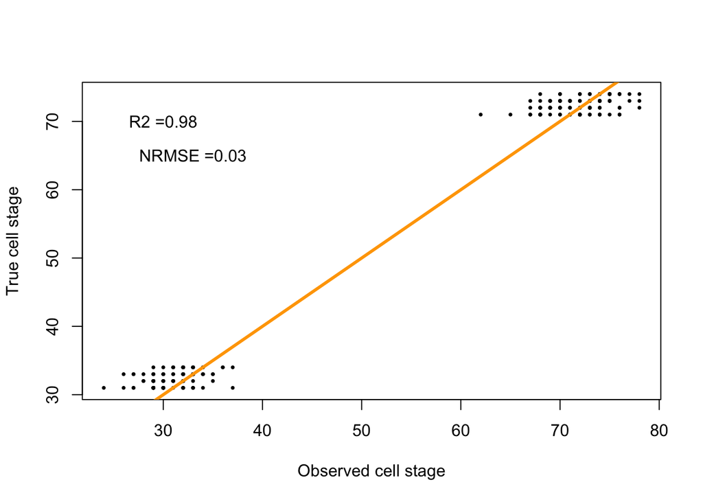

```r
query_b2 = b2_sub@assays$originalexp@data[rownames(ref),]
query_b2 = as.data.frame(query_b2)
query_id = stageAssign(count = query_b2,kernel = log2(ref+1))
query_id = as.data.frame(query_id)
query_id$lineage_cosine = as.numeric(query_id$lineage_cosine)
query_id$score_cosine = as.numeric(query_id$score_cosine)
query_id$step =  b2_sub$Step
NRMSE = RMSE(query_id$lineage_cosine,query_id$step)/99
R2 = R2_Score(query_id$lineage_cosine,query_id$step)

plot(query_id$lineage_cosine,
     query_id$step,pch=16,cex=.5,
     xlab="Observed cell stage",
     ylab="True cell stage")
lines(x=1:100,y=1:100, lwd = 3, col = 'orange')
text(x = 30, y = 70, labels = paste0("R2 =",round(R2,2)))
text(x = 33, y = 65, labels = paste0("NRMSE =",round(NRMSE,2)))
```

#### Data integration

```r
# next we use psuedotime kernel to generate anchors and assign the b1 and b2 sub cells to these anchors
count1= as.data.frame(b1_sub@assays$originalexp@counts)
count2=as.data.frame(b2_sub@assays$originalexp@counts)

bm_stalt_corrected =staltIntegration(count1=count1,count2=count2, genes=VariableFeatures(bm), nPoints = 100,ref=ref)
```

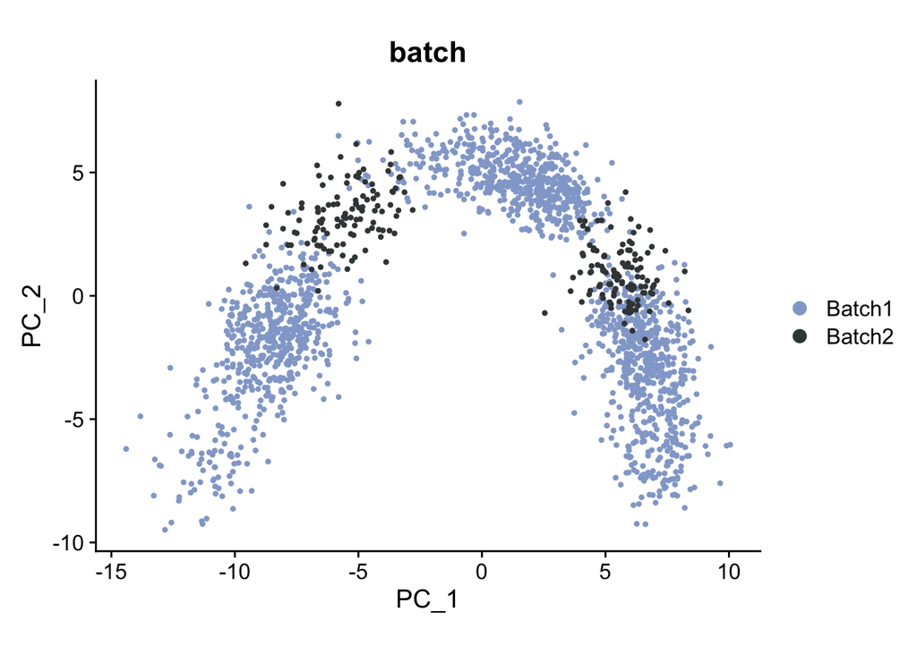

```r
bm_stalt_corrected = CreateSeuratObject(bm_stalt_corrected)
bm_stalt_corrected$batch = bm$Batch
bm_stalt_corrected$col = bm$col
bm_stalt_corrected$step = c(b1_sub$Step,b2_sub$Step)
#bm_stalt_corrected$lineage =c(b1_id$lineage_cosine,b2_id$lineage_cosine)
bm_stalt_corrected = NormalizeData(bm_stalt_corrected)
bm_stalt_corrected = FindVariableFeatures(bm_stalt_corrected)
bm_stalt_corrected = ScaleData(bm_stalt_corrected )
bm_stalt_corrected = RunPCA(bm_stalt_corrected )

DimPlot(bm_stalt_corrected ,group.by = "batch",
        reduction = "pca",
        cols = c("#92a8d1","#3e4444"))+coord_fixed(ratio=1)
```

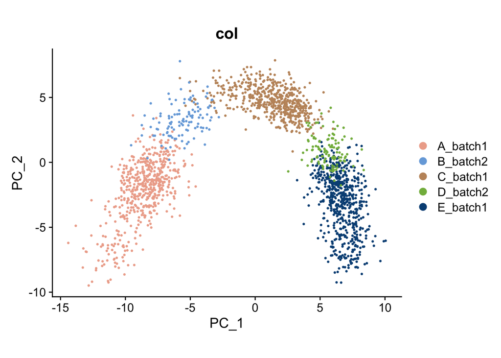

```r
DimPlot(bm_stalt_corrected ,group.by = "col",
        cols = clustercol,
        pt.size = .5)+coord_fixed(ratio=1)
```